# Project1

## Student names and IDs

1. Name:- Harsh Parmar  
   Student_Id:- 0779093
2. Name:- Nishil Patel  
   Student_Id:- 0782837
3. Name:- Raman Keshari  
   Student_Id:- 0783376
4. Name:- Shreyas Mahendra  
   Student_Id:- 0770049
5. Name:- Priyanka Harsukhbhai Ghetiya  
   Student_Id:- 0779258

## Group Number

Group 01 (Gp1)

## Project Disclaimer

The project 1 has been developed and created by the above mentioned members, this project work represents our own work with collaboration and team work. Team has followed all the guidelines and code of conduct adhering to St. Clair College’s Academic Integrity policies.  
All the efforts and work displaying the following is achieved with equal efforts by each individual.

## Rversion

R version 4.0.5 (2021-03-31)

## Rstudio

Version 1.4.1106

## List of R packages used

- tidyverse ‘1.3.1’
- ggplot2 ‘3.3.3’
- gganimate ‘1.0.7’
- gifski ‘1.4.3.1’

## Load library

```r
library(tidyverse)
library(ggplot2)
library(gganimate)
library(gifski)
```

## Documentation of the data sets:

### Attribution of the owner/creator of the data

The creator/owner of the dataset is Mariya Stavnichuk and Tatsuya Corlett.

### Link to the dataset

https://github.com/rfordatascience/tidytuesday/blob/master/data/2020/2020-07-14/readme.md

### Summary information about the data

This database contains publically available information about all astronauts who participated in space missions before 15 January 2020 collected from NASA, Roscosmos, and fun-made websites. The provided information includes full astronaut name, sex, date of birth, nationality, military status, a title and year of a selction program, and information about each mission completed by a particular astronaut such as a year, ascend and descend shuttle names, mission and extravehicular activity (EVAs) durations.

The basic records are complete for people who have flown. This includes name, birth date, birth place, nationality, and the sequential listing of flights including dates and duration. In instances where an individual does not return on the same flight which took him/her into space, the upload flight is listed first, followed by the down load flight. Still to be added are education, etc.

### Documentation of any changes made to the original data sets, if applicable

The Dataset is not changed/altered/filtered in any aspect for this project.

## Importing the Dataset

```r
astronauts <- readr::read_csv('https://raw.githubusercontent.com/rfordatascience/tidytuesday/master/data/2020/2020-07-14/astronauts.csv')
```

### Plot 1

The following code uses a Histogram plot to demonstrate the data visualization of distribution of a single continuous variable year_of_selection using ggplot2. The code includes titles, subtiles and captions using the labs function, formating the axis texts using theme function and theme change using theme_minimal function. The plot dispalys the number of Astronauts selected in a particular year.

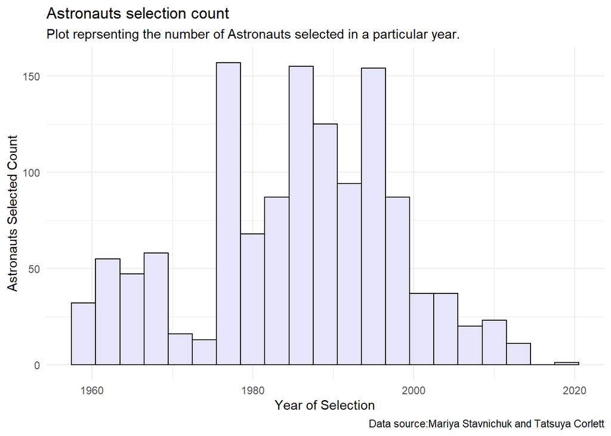

```r
ggplot(data= astronauts)+
  geom_histogram(mapping= aes(x=year_of_selection),
                 color='black',
                 fill='#E6E6FA',
                 binwidth = 3)+
  labs(title ="Astronauts selection count", subtitle ="Plot reprsenting the number of Astronauts selected in a particular year.", caption ="Data source:Mariya Stavnichuk and Tatsuya Corlett") +
  xlab("Year of Selection") + ylab("Astronauts Selected Count")+
  theme(axis.text=element_text(size=10), axis.title=element_text(size=15,face="bold"),
        plot.title = element_text(size=17))+
  theme_minimal()
```

### Plot 2

The following code uses a Histogram plot to demonstrate the data visualization of distribution of a single continuous variable year_of_birth using ggplot2. The code includes titles, subtiles and captions using the labs function, formating the axis texts using theme function and theme change using theme_minimal function. The plot dispalys the Astronauts Year of birth with gender.

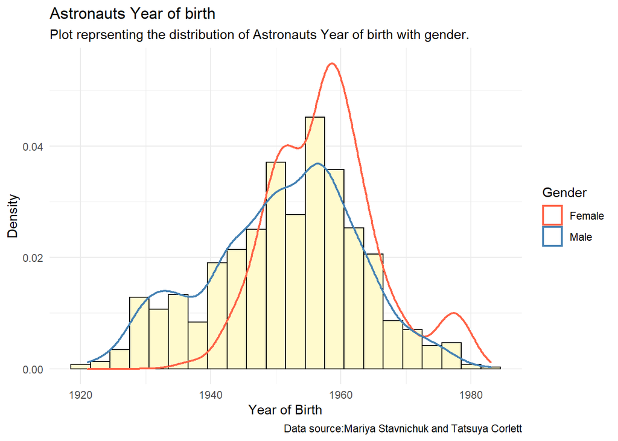

```r
ggplot(data= astronauts)+
  geom_histogram(mapping= aes(x=year_of_birth, y=..density..),
                 color='black',
                 fill='#FFFACD',
                 binwidth = 3,
                 position="identity")+
  geom_density(mapping= aes(x=year_of_birth, color=sex), size=0.72)+
  labs(title ="Astronauts Year of birth", subtitle ="Plot reprsenting the distribution of Astronauts Year of birth with gender.", caption ="Data source:Mariya Stavnichuk and Tatsuya Corlett", color="Gender") +
  scale_color_manual(labels = c("Female", "Male"), values = c("tomato", "steelblue"))+
  xlab("Year of Birth") + ylab("Density")+
  theme(axis.text=element_text(size=10), axis.title=element_text(size=14,face="bold"),
        plot.title = element_text(size=17))+
  theme_minimal()
```

### Plot 3

The following code uses a Bar plot to demonstrate the information about a single categorical variable occupation using ggplot2. The code includes titles, subtiles and captions using the labs function, formating the axis texts using theme function, theme change using theme_minimal function and coord_flip to interchange the X and Y axis variables. The plot dispalys the count of different occupations of Astronauts.

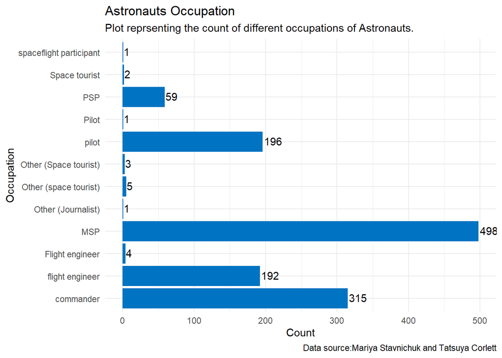

```r
ggplot(data= astronauts)+
  geom_bar(mapping= aes(x=occupation), fill = "#0073C2FF")+
  geom_text(mapping= aes(x=occupation, label=..count..),stat='count',hjust=-0.07,vjust=0.4)+
  labs(title ="Astronauts Occupation", subtitle ="Plot reprsenting the count of different occupations of Astronauts.", caption ="Data source:Mariya Stavnichuk and Tatsuya Corlett")+
  xlab("Occupation") + ylab("Count")+
  theme(axis.text=element_text(size=10), axis.title=element_text(size=15,face="bold"),
        plot.title = element_text(size=17))+
  theme_minimal()+
  coord_flip()
```

### Plot 4

The following code uses a Bar plot to demonstrate the information about a single categorical variable occupation using ggplot2. The code includes titles, subtiles and captions using the labs function, formating the axis texts using theme function, theme change using theme_minimal function and coord_flip to interchange the X and Y axis variables. The plot dispalys the military status of Astronauts with different occupations.

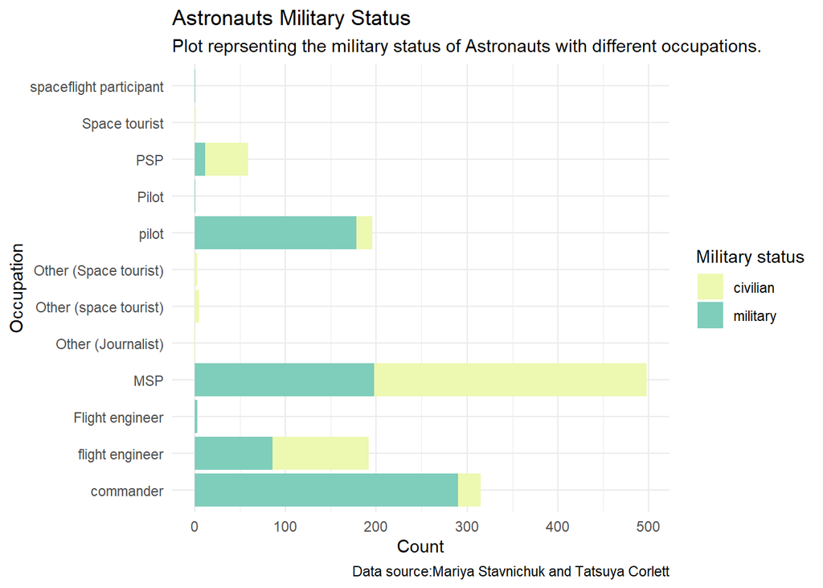

```r
ggplot(data=astronauts)+
  geom_bar(mapping = aes(x=occupation, fill=military_civilian))+
  scale_fill_brewer(palette="YlGnBu")+
  labs(title ="Astronauts Military Status", subtitle ="Plot reprsenting the military status of Astronauts with different occupations.", caption ="Data source:Mariya Stavnichuk and Tatsuya Corlett", fill="Military status")+
  xlab("Occupation") + ylab("Count")+
  theme(axis.text=element_text(size=10), axis.title=element_text(size=15,face="bold"),
        plot.title = element_text(size=17))+
  theme_minimal()+
  coord_flip()
```

### Plot 5

The following code uses a jitter plot to demonstrate the information about both a continuous variable year_of_birth and a categorical variable nationality using ggplot2. The code includes titles, subtiles and captions using the labs function, formating the axis texts using theme function, theme change using theme_minimal function and coord_flip to interchange the X and Y axis variables. The plot dispalys the information of personal details of Astronauts.

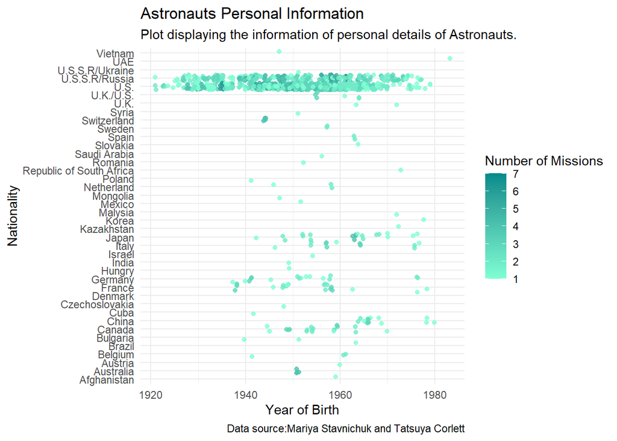

```r
ggplot(data=astronauts)+
  geom_jitter(mapping = aes(x=nationality   , y=year_of_birth, color=total_number_of_missions), alpha=0.8)+
  scale_color_gradient(low = "#7FFFD4", high = "#008B8B") +
  labs(title ="Astronauts Personal Information", subtitle ="Plot displaying the information of personal details of Astronauts.", caption ="Data source:Mariya Stavnichuk and Tatsuya Corlett", color="Number of Missions")+
  xlab("Nationality") + ylab("Year of Birth")+
  theme(axis.text=element_text(size=10), axis.title=element_text(size=15,face="bold"),
        plot.title = element_text(size=17))+
  theme_minimal()+
  coord_flip()
```

### Plot 6

The following code uses a jitter plot to demonstrate the information that shows a relationship between two variables year_of_selection and nationwide_number using ggplot2. The code includes titles, subtiles and captions using the labs function, formating the axis texts using theme function and theme change using theme_minimal function. The plot dispalys the information of Astronauts Number within country and the year of selection.

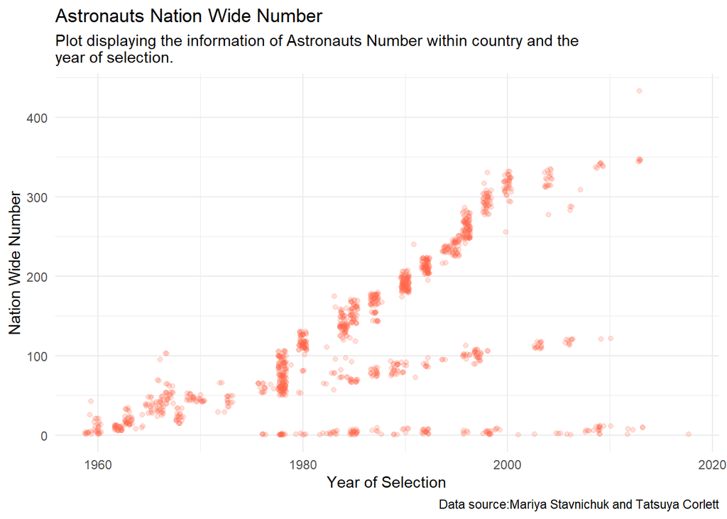

```r
ggplot(data=astronauts)+
  geom_jitter(mapping = aes(x=year_of_selection,y= nationwide_number ),color="tomato", alpha = 0.2)+
  labs(title ="Astronauts Nation Wide Number", subtitle ="Plot displaying the information of Astronauts Number within country and the \nyear of selection.", caption ="Data source:Mariya Stavnichuk and Tatsuya Corlett")+
  xlab("Year of Selection") + ylab("Nation Wide Number")+
  theme(axis.text=element_text(size=10), axis.title=element_text(size=15,face="bold"),
        plot.title = element_text(size=17))+
  theme_minimal()
```

### Plot 7

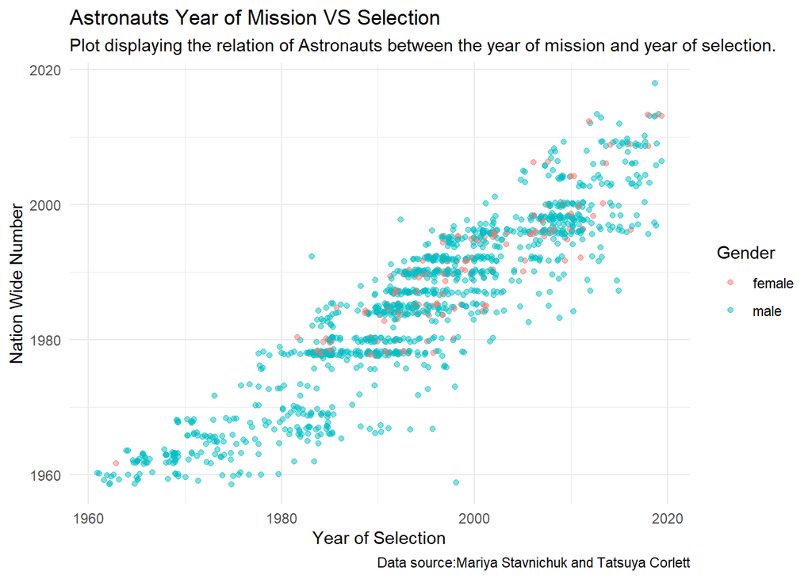

```r
ggplot(data=astronauts)+
  geom_jitter(mapping = aes(x=year_of_mission,y= year_of_selection, color=sex ), alpha = 0.5)+
  labs(title ="Astronauts Year of Mission VS Selection", subtitle ="Plot displaying the relation of Astronauts between the year of mission and year of selection.", caption ="Data source:Mariya Stavnichuk and Tatsuya Corlett", color="Gender")+
  xlab("Year of Selection") + ylab("Nation Wide Number")+
  theme(axis.text=element_text(size=10), axis.title=element_text(size=15,face="bold"),
        plot.title = element_text(size=17))+
  theme_minimal()
```

### Plot 8

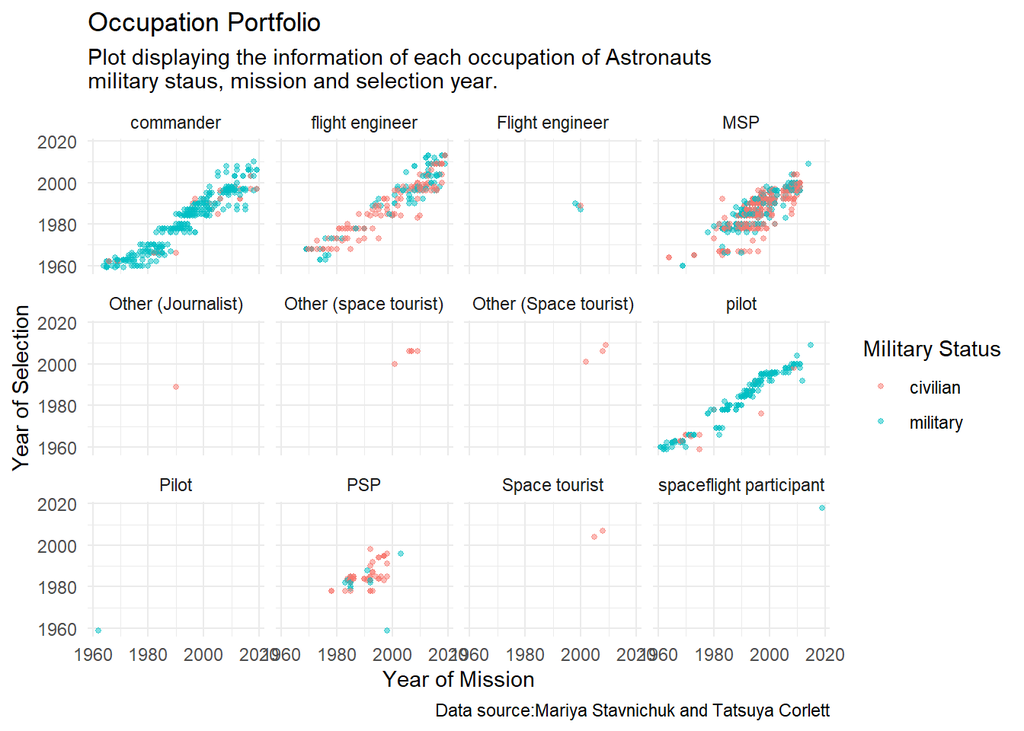

```r
ggplot(data=astronauts)+
  geom_point(mapping = aes(x=year_of_mission    , y= year_of_selection, color=military_civilian ), size=1, alpha=0.5)+
  facet_wrap(facet= vars(occupation))+
  labs(title ="Occupation Portfolio", subtitle ="Plot displaying the information of each occupation of Astronauts \nmilitary staus, mission and selection year.", caption ="Data source:Mariya Stavnichuk and Tatsuya Corlett", color="Military Status")+
  xlab("Year of Mission") + ylab("Year of Selection")+
  theme(axis.text=element_text(size=10), axis.title=element_text(size=15,face="bold"),
        plot.title = element_text(size=17))+
  theme_minimal()
```

### Plot 9

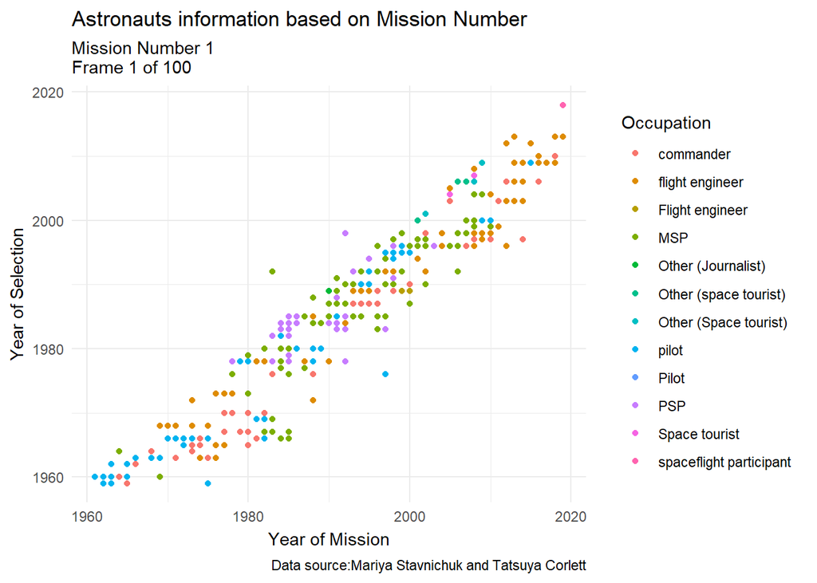

```r
ggplot(data=astronauts)+
  geom_point(mapping = aes(x=year_of_mission, y=year_of_selection, color=occupation))+
  transition_states(mission_number,transition_length = 2,
                    state_length = 1) +
   ggtitle('Astronauts information based on Mission Number',
          subtitle = 'Mission Number {closest_state} \nFrame {frame} of {nframes}')+
  labs(caption="Data source:Mariya Stavnichuk and Tatsuya Corlett", color="Occupation")+
  xlab("Year of Mission") + ylab("Year of Selection")+
  theme(axis.text=element_text(size=10), axis.title=element_text(size=15,face="bold"),
        plot.title = element_text(size=17))+
  theme_minimal()
```

### References to any external sources used and how they were used

https://www.r-bloggers.com/  
https://cran.r-project.org/web/packages/gganimate/  
https://plotly.com/ggplot2/  
http://www.sthda.com/english/  
https://www.datanovia.com/en/  
https://www.r-graph-gallery.com/

The above websites/content were used to enhance the plots visually and use functions to include different colors, palette and to align the plot attributes like axis text and titles. The websites were also used to explore new functions to make the plot attractive.

### In what ways do you think data visualization is important to understanding a dataset?

- Data visualization is the visual presentation of data or information. The goal of data visualization is to communicate data or information clearly and effectively to readers.
- Data can be plotted in the form of scatterplots, histogram, bar graphs, line graphs etc.
- Data visualization gives us a clear idea of what the information means by giving it visual context through maps or graphs. It makes the data more familiar and understandable for the human mind to comprehend and therefore makes it easier to identify trends, patterns and outliers within large data sets.

### In what ways do you think data visualization is important to communicating important aspects of a data set?

- Data visualization helps to quickly and clearly tell the story that the numbers in a dataset represents.
- To avoid the complex datasets or detailed reports and to get the required information to take actions and make decisions. A graphical or pictorial representation, can provide the same information efficiently and attractively.
- As a result, good data visualization plays an increasingly important role in conveying the information embedded in corporate data sets to business decision-makers.

### What role does your integrity as an analyst play when creating a data visualization for communicating results to others?

- As an analyst when creating data visualization a good depiction of dataset plays an increasingly important role in conveying the information in the business of decision-making.
- As an analyst we should provide a best result through which the optimum decisions are taken according to the business needs. The graphs and models should be such finely represented that anyone can easily interpret the data with ease.

### How many variables do you think you can successfully represent in a visualization? What happens when you exceed this number?

- Depending on the dataset, if it is poured with multiple variables then it will become more complex for the analyst to read and gain useful interpretation from it.
- The dataset should contain categorical and continuous variables which makes the dataset less complex and easy to read.
- If the number of variables exceeds after a certain level or point the graph will result in over plotting and the data would look messy which leads to an uncertain results.

### Briefly note about contributions of each team member

Each team member worked on deciding the dataset and performing Data-visualization on all the plots and played different individual roles.  
Harsh Parmar- Dataset selection, Data-visualization and information gathering.  
Nishil Patel- Dataset selection, Data-visualization and data interpretation.  
Raman Keshari- Dataset selection, Data-visualization and Rmd file formatting.  
Shreyas Mahendra- Dataset selection, Data-visualization and optimization of plots.  
Priyanka Harsukhbhai Ghetiya- Dataset selection, Data-visualization and exploration of different functions.